# Question

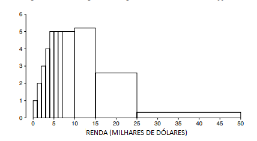

Cerca de 1% das famílias na figura tem renda entre $0 e $1000.

Estime a porcentagem que tem renda

- Entre 1000 e 2000
- Entre 2000 e 3000
- Entre 2000 e 10000
- Entre 1000 e 10000
- Entre 3000 e 4000
- Entre 4000 e 10000

As porcentagens são, respectivamente:

## Answerlist

- 2%, 6%, 40%, 38%, 5%, 27%
- 6%, 6%, 35%, 37%, 3%, 32%
- 2%, 3%, 40%, 40%, 2%, 30%
- 2%, 3%, 37%, 39%, 4%, 30%
- 4%, 3%, 35%, 40%, 6%, 30%

# Solution

Analisando o gráfico, observa-se que se 1% das famílias têm renda entre $0 e $1000 dólares, então: 2% têm renda entre $1000 e $2000 dólares; 3% têm renda entre $2000 e $3000 dólares; e assim por diante.

Então vamos, por exemplo, para determinar a porcentagem de famílias com renda entre $1000 e $4000:

Para isso, note que estas famílias são exatamente as famílias com renda entre $1000 e $2000 dólares (2%), mais as famílias com renda entre $2000 e $3000 dólares (3%), mais a famílias com renda entre $3000 e $4000 dólares (4%), somando um total de 2+3+4=9% das famílias.

## Answerlist

- Incorreta
- Incorreta
- Incorreta
- Correta
- Incorreta